# Gene expression of L. plantarum WCFS1

#### Filteren

```r
WCFSfinal <- filter(WCFSglcribres$table,  WCFSglcribres$table$FDR<0.005 &(WCFSglcribres$table$logFC>1|WCFSglcribres$table$logFC<(-1)))
```

NC8 glucose vs NC8 ribose

```r
NC8final <- filter(NC8glcribres$table,  NC8glcribres$table$FDR<0.005 &(NC8glcribres$table$logFC>1|NC8glcribres$table$logFC<(-1)))
```

Annotatie toevoegen aan de genen die zijn gefiltered en van hoog naar laag sorteren

```r
WCFS1_sig <- cbind(WCFSfinal, annotation[rownames(WCFSfinal),])
NC8_sig <- cbind(NC8final, annotation[rownames(NC8final),])
WCFS1_sorted <- WCFS1_sig[order(WCFS1_sig[, "logFC"], decreasing = TRUE, na.last = FALSE), ,drop=FALSE]
NC8_sorted <- NC8_sig[order(NC8_sig[, "logFC"], decreasing = TRUE, na.last = FALSE), ,drop=FALSE]
```

Excel file maken met de data en annotaties

```r
#write.xlsx(WCFS1_sorted, file = "Merged_Genes.xlsx", sheetName = "WCFS1_data",
#  col.names = TRUE, row.names = TRUE, append = FALSE)
#write.xlsx(NC8_sorted, file = "Merged_Genes.xlsx", sheetName = "NC8_data",
#  col.names = TRUE, row.names = TRUE, append = TRUE)
```

#### KEGG Mapper

```r
WCFS1_final_names <- c(rownames(head(WCFS1_sorted, 5)), rownames(tail(WCFS1_sorted, 5)))
WCFS1<-data.frame(WCFS1_final_names)
WCFS1$logFC<-c((head(WCFS1_sorted, 5)$logFC), (tail(WCFS1_sorted, 5)$logFC))
NC8_final_names <- c(rownames(head(NC8_sorted, 5)), rownames(tail(NC8_sorted, 5)))
NC8<-data.frame(NC8_final_names)
NC8$logFC<-c((head(NC8_sorted, 5)$logFC), (tail(NC8_sorted, 5)$logFC))
```

#### Heat Map

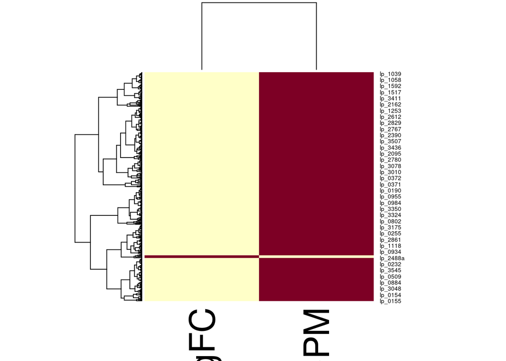

```r
# Sorry ik was verkeerde aan het doen mischien heb je er wel wat aan
HMNC8 = data.matrix(NC8final %>% select(-(LR:FDR)))
heatmap(HMNC8)
```

## Resultaten

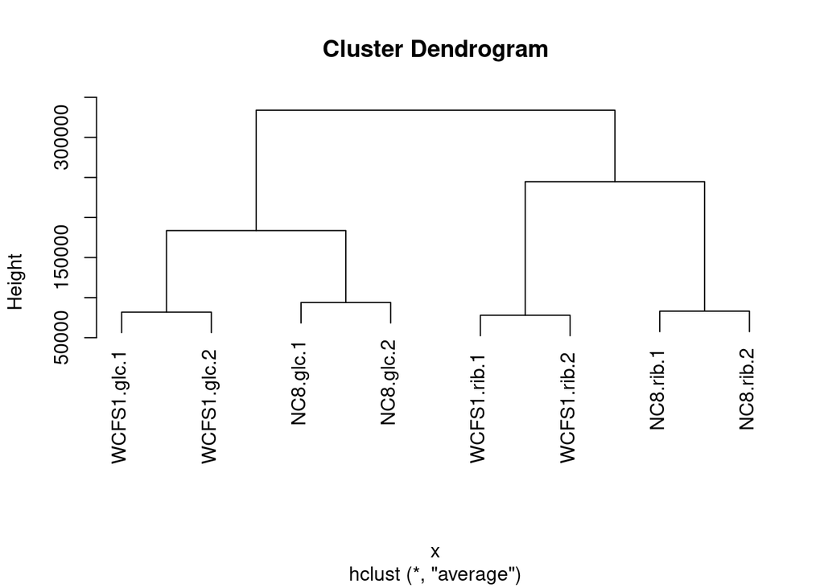

```r
x <- t(y$counts)
x <- dist(x, method = "euclidean")
x <- hclust(x, method = "average")
plot(x)
```

#### PCA plot

De PCA plot (principal component analysis) comprimeert de datasets door de data zo veel mogelijk om te zetten naar de 1ste dimensies. Het verminderen van dimensies van de variatie in de samples maakt het mogelijk om de ze gemakkelijk te visualiseren en met elkaar te vergelijken. De X en Y as geven de fold-change in de log2 schaal weer. De X-as verklaart de hoogste variatie, in dit geval laat het zien dat het verschil in fold-change tussen WCFS1.glucose en WCFS1.ribose zeer groot is. Daarbij valt ook op dat de groepen die in de design matrix gemaakt zijn weinig variatie met elkaar hebben.

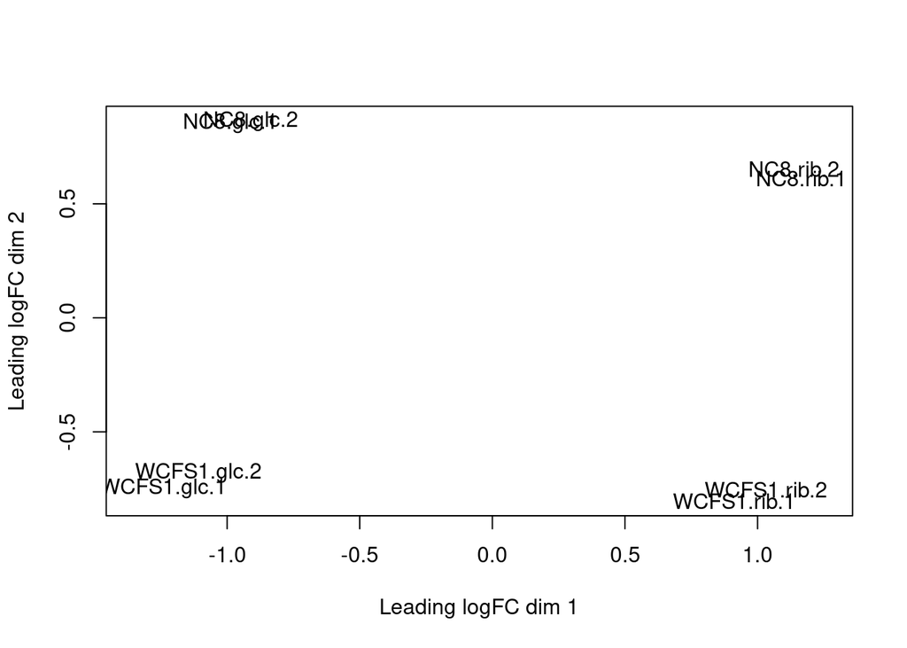

```r
plotMDS(y)
```

#### Dispersie plot

De dispersie plot laat de spreiding van de data zien. Dit zegt iets over hoe goed de verschillende samples met elkaar te vergelijken zijn. Op de X-as staat de CPM (counts per million) op de log schaal en Y-as de dispersie. De rode lijn is de common, het ideale scenario. De blauwe lijn laat de afwijking zien van variatie van de verschillende samples. Hier is te zien dat de trendlijn redelijk overeen komt met de common lijn.

```r
plotBCV(y)
```

[output not shown]

[figure not shown]

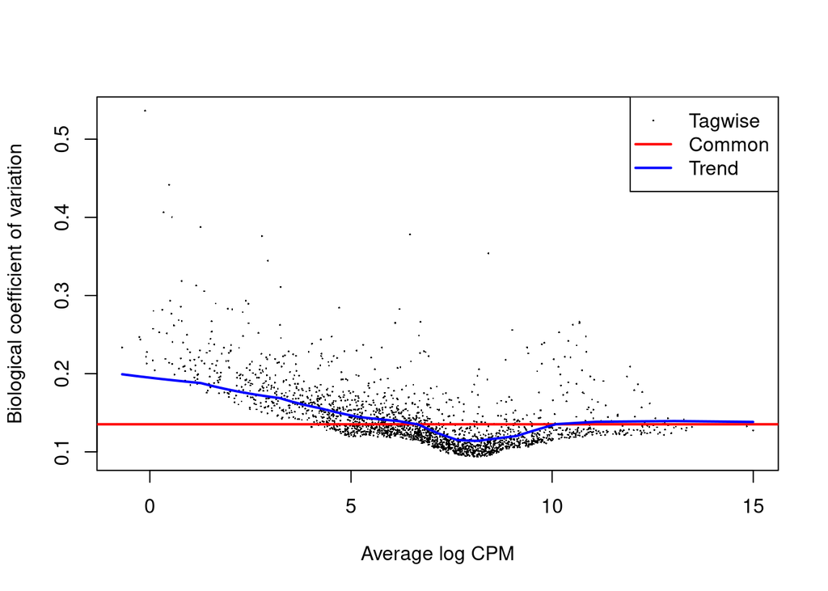

```r
plotBCV(f)
```

### Fit data

```r
fit <- glmFit(y,design)
```

### Determine fold changes

```r
mc <- makeContrasts(exp.r=WCFS1.glc-WCFS1.rib, levels=design)

fit <- glmLRT(fit, contrast=mc)
```

### Print top tags

```r
res<-topTags(fit)
print(res)
```

```
## Coefficient:  1*WCFS1.glc -1*WCFS1.rib
##             logFC    logCPM        LR        PValue           FDR
## lp_3658 -8.133346 12.115754 1246.7823 4.152896e-273 9.132218e-270
## lp_2154 -5.889552 10.206499  882.6949 5.672578e-194 6.236999e-191
## lp_2151 -5.971299 11.156879  881.2502 1.169103e-193 8.569523e-191
## lp_3660 -8.397810 11.386324  855.8486 3.891043e-188 2.139101e-185
## lp_0371 -5.667077  8.972546  852.1526 2.475123e-187 1.088559e-184
## lp_3659 -8.140450 11.024045  831.0170 9.740349e-183 3.569838e-180
## lp_2152 -6.031264 11.033466  789.5167 1.026434e-173 3.224470e-171
## lp_2153 -5.913012 10.440918  752.9862 8.996830e-166 2.473004e-163
## lp_0575  4.688790  9.926790  671.7358 4.189105e-148 1.023538e-145
## lp_2757 -4.067633  7.587633  648.5245 4.677423e-143 1.028565e-140
```

[figure not shown]

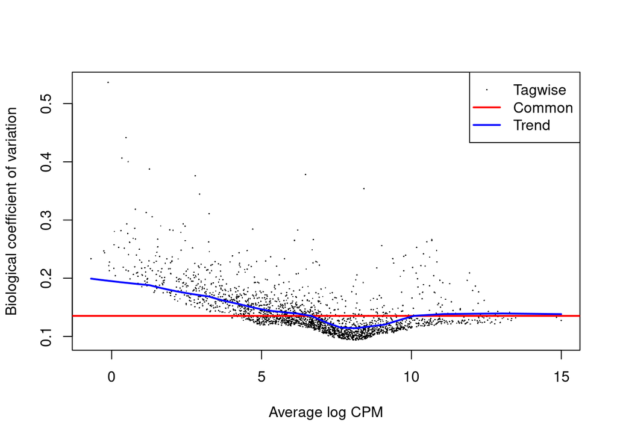

```r
plotBCV(f)
```

#### K-means

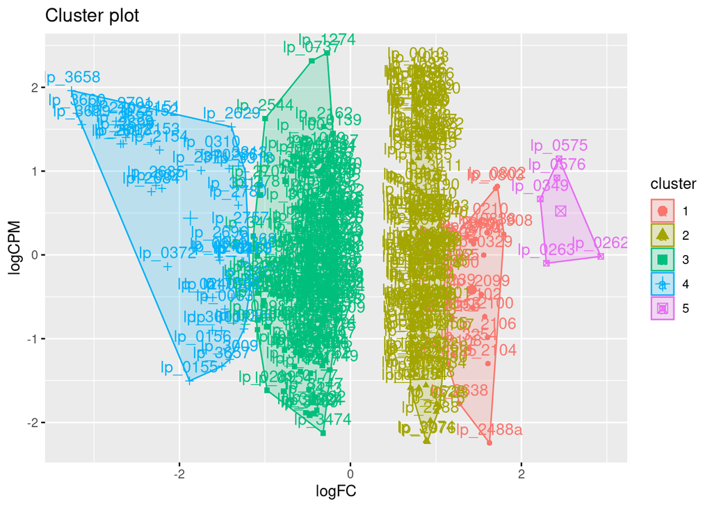

```r
km <- kmeans((NC8final %>% select(-(logCPM:FDR))), centers = 5)
fviz_cluster(km, data = (NC8final %>% select(-(LR:FDR))))
```